# D-score uit VWO voor GGData

Author

Iris Eekhout & Laurens van Buren

## Setup

Voor het opschonen van de data en berekenen van de D-score hebben we een aantal R-packages nodig. Voor het opschonen van de data gebruiken we `tidyr` en `dplyr`. Voor het berekenen en weergeven van de D-score gebruiken we `dscoreddi`, `dscore` en `ggplot2`. Voor het weergeven van tabellen gebruiken we `knitr`.

De packages over de D-score staan openbaar gepubliceerd op Github. Deze kun je dus vanuit die locaties vrij installeren met behulp van het `remotes` package. Hieronder de R-code waarmee de benodigde packages geinstalleerd en ingeladen worden.

```r
# Load required CRAN packages
require(dplyr, quietly = TRUE, warn.conflicts = FALSE)
require(tidyr, quietly = TRUE, warn.conflicts = FALSE)
require(ggplot2, quietly = TRUE, warn.conflicts = FALSE)
require(knitr, quietly = TRUE, warn.conflicts = FALSE)

# Load dedicated package for reading GSED data
if (!requireNamespace("dscoreddi", quietly = TRUE) && interactive()) {
  answer <- askYesNo(paste("Package", pkg, "needed. Install from GitHub?"))
  if (answer) remotes::install_github("d-score/dscoreddi")
}
if (!requireNamespace("dscore", quietly = TRUE) && interactive()) {
  answer <- askYesNo(paste("Package dscore needed. Install from GitHub?"))
  if (answer) remotes::install_github("d-score/dscore")
}

require(dscoreddi, quietly = TRUE, warn.conflicts = FALSE)
require(dscore, quietly = TRUE, warn.conflicts = FALSE)
```

## Extractie van data

- Persoonnummer
- ContactmomentID
- Leeftijd in dagen
- Mijlpalen van Wiechen

Leeftijd en mijlpalen per contactmoment

**Oefendata**

- `jgz_background`: Achtergronddata bevat `ID`, `Geboortedatumkind`, `Geslachtkind`, `jaar` en `Gebied`. Een kind kan meerdere jaren in zorg zijn en heeft voor elk van die jaren achtergrondgegevens.
- `jgz_vwo`: Van Wiechen data bevat `ID`, `ContactmomentID`, `Datum`, Van Wiechen items `vW.#`. Een kind kan meerdere contactmomenten hebben per jaar.

*Koppeling van bestanden*

De achtergronddata en de van Wiechendata kunnen gekoppeld worden op basis van ID, maar ook `jaar` moet erbij betrokken worden. Daarvoor moet eerst het “jaar” bepaald worden voor elk contactmoment.

```r
#jgz_vwo
#jaar contactmoment jaar bepalen voor de "Datum" variabele
jgz_vwo <-
  jgz_vwo |> mutate(jaar = as.numeric(format(Datum, "%Y")))

#koppel achtergronddata aan de Van Wiechen-data
vwd_raw <-
  left_join(jgz_vwo, jgz_background, by = c("ID", "jaar"))
```

## Opschonen van data

**Leeftijd berekenen**

Leeftijd berekenen op basis van Datum en geboortedatum. Voor de D-score hebben we leeftijd in jaren nodig (met decimalen), voor weergeven in plaatjes is het soms handig om de leeftijd ook in maanden te hebben.

```r
#leeftijd berekenen
vwd_raw <-
  vwd_raw |>
  mutate(leeftijd = as.numeric(Datum - Geboortedatumkind), #in dagen
         age = leeftijd / 365.25, #in jaren
         agemos = age * 12 #in maanden
         )
```

**Hercoderen**

- ‘-’, ‘+’ en ‘M’ omzetten naar 0 en 1.

```r
vwd <- vwd_raw |>
  mutate(across(starts_with("vW."),
                ~case_when(.x == "-" ~ 0,
                           .x == "+" ~ 1,
                           .x == "M" ~ 1))
  )
```

- Links en Rechts variabelen combineren

```r
vwd <- vwd |>
  mutate(vW.2 = ifelse((vW.2L == 1 & vW.2R == 1), 1, 0),
         vW.3 = ifelse((vW.3L == 1 & vW.3R == 1), 1, 0),
         vW.6 = ifelse((vW.6L == 1 & vW.6R == 1), 1, 0),
         vW.9 = ifelse((vW.9L == 1 & vW.9R == 1), 1, 0),
         vW.10 = ifelse((vW.10L == 1 & vW.10R == 1), 1, 0),
         vW.11 = ifelse((vW.11L == 1 & vW.11R == 1), 1, 0),
         vW.13 = ifelse((vW.13L == 1 & vW.13R == 1), 1, 0),
         vW.15 = ifelse((vW.15L == 1 & vW.15R == 1), 1, 0),
         vW.52 = ifelse((vW.52L == 1 & vW.52R == 1), 1, 0),
         vW.53 = ifelse((vW.53L == 1 & vW.53R == 1), 1, 0),
         vW.59 = ifelse((vW.59L == 1 & vW.59R == 1), 1, 0),
         vW.71 = ifelse((vW.71L == 1 & vW.71R == 1), 1, 0),
         vW.75 = ifelse((vW.75L == 1 & vW.75R == 1), 1, 0))
```

- Kenmerken die in BDS in één veld worden gezet, verdelen in meerderen kenmerken op basis van leeftijd.

```r
vwd <- vwd |>
  mutate( vW.55 = vW.55, #dit is de a eigenlijk
         vW.55b = vW.55,
         vW.55c = vW.55,
         vW.55d = vW.55,
         vW.68a = vW.68,
         vW.68b = vW.68,
         vW.68c = vW.68,
         vW.68 = NULL) #originele weglaten, anders krijgen we 2 dezelfde variabelen.

vwd <- vwd |>
  mutate(vW.55b = ifelse(age < 0.5   / 365.25 | age > 42.5  / 365.25, NA, vW.55b),
         vW.55c = ifelse(age < 42.5  / 365.25 | age > 102.5 / 365.25, NA, vW.55c),
         vW.55d = ifelse(age < 102.5 / 365.25 | age > 146.5 / 365.25, NA, vW.55d),
         vW.55 = ifelse(age < 146.5 / 365.25 | age > 1, NA, vW.55),
         vW.68a = ifelse(age < 0.75 | age >= 1.75, NA, vW.68a),
         vW.68b = ifelse(age < 1.75 | age >= 2.50, NA, vW.68b),
         vW.68c = ifelse(age < 2.5  | age >= 3.50, NA, vW.68c))
```

**Itemnamen in D-score format**

- Bekijk tabel met naam-formaten

```r
dscoreddi::itemtableVWO |> kable()
```

| ID.VWO1996 | ID.VWO2005 | ID.VWO1983 | ID.VWO1983b | occ | month | labelNL | labelEN | item | label | labelNL_duch |
| --- | --- | --- | --- | --- | --- | --- | --- | --- | --- | --- |
| v1 | v1 | v1 | v1430 | 1 | 1 | Ogen fixeren | Fixates eyes | ddifmd001 | Eyes fixate | Ogenfixeren |
| v2 | v2 | v7 | v1438 | 2 | 2 | Volgt met ogen en hoofd | Follows with eyes and head | ddifmd002 | Follows with eyes and head 30d < 0 > 30d | Volgtmetogenenhoofd |
| v3 | v3 | v8 | v1440 | 3 | 3 | Handen af en toe openen | Hands open occasionally | ddifmd003 | Hands open occasionally | Handenafentoeopen |
| v4 | v4 | v9 | v1442 | 3 | 3 | Kijkt naar eigen handen | Watches own hands | ddifmm004 | Watches own hands | Kijktnaareigenhanden |
| v5 | v5 | v13 | v1446 | 4 | 6 | Speelt met handen middenvoor | Plays with hands in midline | ddifmd005 | Plays with hands in midline | Speeltmethandenmiddenvoor |
| v6 | v6 | v14 | v1447 | 4 | 6 | Pakt in rugligging voorwerp binnen bereik | Grasps object within reach | ddigmd006 | Grasps object within reach | Paktinrugliggingvoorwerp |
| v7 | v7 | v19 | v1455 | 5 | 9 | Pakt blokje over | Passes cube from hand to hand | ddifmd007 | Passes cube from hand to hand | Paktblokjeover |
| v8 | v8 | v20 | v1456 | 5 | 9 | Houdt blokje vast, pakt er nog een in andere hand | Holds cube, grasps another one with other hand | ddifmd008 | Holds cube, grasps another one with other hand | Houdtblokjevastpakternogeeninanderehand |
| v9 | v9 | v21 | v1457 | 5 | 9 | Speelt met beide voeten | Plays with both feet | ddifmm009 | Plays with both feet | Speeltmetbeidevoeten |
| v10 | v10 | v27 | v1464 | 6 | 12 | Pakt propje met duim en wijsvinger | Picks up crumb between thumb and index finger | ddifmd010 | Picks up pellet between thumb and index finger | Paktpropjemetduimenwijsvinger |
| v11 | v11 | v32 | v1470 | 7 | 15 | Doet blokje in/uit doos | Puts cube in and out of a box | ddifmd011 | Puts cube in and out of a box | Doetblokjeinuitdoos |
| v12 | v12 | v33 | v1472 | 7 | 15 | Speelt geven en nemen (M) | Plays give and take | ddifmm012 | Plays ‘give and take’ (M; can ask parents) | Speeltgevenennemen |
| v13 | v13 | v38 | v1512 | 8 | 18 | Stapelt 2 blokjes - rl | Makes tower of two cubes | ddifmd013 | Tower of 2 cubes | Stapelttweeblokjes |
| v14 | v14 | v39 | v1514 | 8 | 18 | Gaat op onderzoek uit (M) | Explores environment energetically (M; can ask parents) | ddifmm014 | Explores environment energetically (M; can ask parents) | Gaatoponderzoekuit |
| v15 | v15 | v44 | v1520 | 9 | 24 | Stapelt 3 blokjes - rl | Makes tower of three cubes | ddifmd015 | Builds tower of 3 cubes | Stapelt3blokjes |
| v16 | v16 | v45 | v1522 | 9 | 24 | Doet anderen na (M) | Imitates everyday activities | ddifmm016 | Imitates everyday activities (M; can ask parents) | Doetanderenna |
| v17 | v17 | NA | v1528 | 10 | 30 | Stapelt 6 blokjes | Makes tower of six cubes | ddifmd017 | Tower of 6 cubes | Stapelt6blokjes |
| v18 | v18 | NA | v1529 | 10 | 30 | Plaatst ronde vorm in stoof | Places round block in board | ddifmd018 | Places round block in board | Plaatstrondevorminstoof |
| v19 | v19 | NA | v1530 | 10 | 30 | Trekt kledingstuk uit (M) | Takes off a cloth (shoe, sock, trousers) | ddifmm019 | Takes off shoes and socks (M; can ask parents) | Trektkledingstukuit |
| v20 | v20 | NA | NA | 11 | 36 | Bouwt vrachtauto na | Imitates building a truck | ddifmd020 | Imitates building a truck | Bouwtvrachtautona |
| v21 | v21 | NA | NA | 11 | 36 | Plaatst 3 vormen in stoof | Places 3 forms in form-box | ddifmd021 | Places 3 forms in form-box | Plaatst3vormeninstoof |
| v22 | v22 | NA | NA | 11 | 36 | Tekent verticale lijn na | Imitates drawing vertical line | ddifmd022 | Imitates drawing vertical line | Tekentverticalelijnna |
| v23 | v23 | NA | NA | 12 | 42 | Bouwt brug na | Imitates building a bridge | ddifmd023 | Imitates building a bridge | Bouwtbrugna |
| v24 | v24 | NA | NA | 12 | 42 | Plaatst 4 vormen in stoof | Places 4 forms in form-box | ddifmd024 | Places 4 forms in form-box | Plaatst4vormeninstoof |
| v25 | v25 | NA | NA | 12 | 42 | Trekt eigen kledingstuk aan (M) | Can dress (one piece) (M; can ask parents) | ddifmm025 | Can dress (one piece) (M; can ask parents) | Trekteigenkledingstukaan |
| v26 | v27 | NA | NA | 13 | 48 | Houdt potlood met vingers vast | Holds pencil with fingers | ddifmd027 | Holds pencil with fingers | Houdtpotloodmetvingersvast |
| v27 | v26 | NA | NA | 13 | 48 | Tekent cirkel na | Copies a circle | ddifmd026 | Copies a circle | Tekentcircelna |
| v28 | v29 | v2 | v1431 | 1 | 1 | Reageert op toespreken (M) | Reacts when spoken to | ddicmm029 | Reacts when spoken to | Reageertoptoespreken |
| v29 | v30 | v6 | v1437 | 2 | 2 | Lacht terug (M) | Smiles in response (M; can ask parents) | ddicmm030 | Smiles in response (M; can ask parents) | Lachtterug |
| v30 | v31 | v10 | v1443 | 3 | 3 | Maakt geluiden terug (M) | Vocalizes responsively | ddicmm031 | vocalizes in response | Maaktgeluidenterug |

[output cut: 59 more lines]

- Hernoemen van de kolommen naar `item`

```r
#rename column names to gsed names to compute d-scores
vwnames <- colnames(vwd)[grepl("^vW.[1-9]", colnames(vwd))]

vwnames <- gsub("^vW.", "v", vwnames)
vwnames2 <- rename_vwo_gsed(vwnames)

#pas renames toe op data
colnames(vwd)[grepl("^vW.[1-9]", colnames(vwd))] <- vwnames2
```

- *OPTIE:* doorscoren en terugminnen van de item-scores

```r
# Leeftijdsgrens voor de items in het Van Wiechen toevoegen aan de itemtabel
## age limit is next cm age
cm_max <- data.frame(
  month =   c(1, 2, 3, 6,  9, 12, 15, 18, 24, 30, 36, 42, 48, 55),
  max_lft = c(2, 3, 6, 9, 12, 15, 18, 24, 30, 36, 42, 48, 55, 78),
  min_lft = c(0, 1, 2, 3,  6,  9,  12, 15, 18, 24, 30, 36, 42, 48 )
)

itemtableVWO <- itemtableVWO |> select(item, labelNL, occ, month) |>
  left_join(cm_max, by = "month") |> select(item, labelNL, occ, month, min_lft, max_lft)

vwd_add_limit <-
vwd |>
 pivot_longer(cols = starts_with("ddi"), names_to ="item", values_to = "score") |>
  left_join(itemtableVWO |> select(item, min_lft, max_lft), by = "item") |>
  group_by(ID, item) |>
  mutate(max_age_zero = ifelse(any(score == 0), max(agemos[which(score == 0)]), -Inf),
         min_age_one = ifelse(any(score == 1), min(agemos[which(score == 1)]), Inf),

         score = ifelse(is.na(score) & agemos < max_age_zero & agemos > min_lft, 0, score),
         score = ifelse(is.na(score) & agemos > min_age_one & agemos < max_lft, 1, score)
         ) |>
  select(-max_age_zero, -min_age_one, -min_lft, -max_lft) |>
  ungroup() |>
  pivot_wider(names_from = "item", values_from = "score")
```

## Bekijk de data voor vijf random kinderen

```r
set.seed(654645)
vwd |>
  select(age, colnames(vwd)[grepl("^ddi", colnames(vwd))]) |>
  slice_sample(n=5) |>
  kable()
```

| age | ddifmd020 | ddifmd021 | ddifmd022 | ddicmm045 | ddicmm046 | ddigmm073 | ddifmd023 | ddifmd024 | ddifmm025 | ddifmd026 | ddifmd027 | ddigmd074 | ddicmm039 | ddicmm040 | ddicmm041 | ddicmm043 | ddicmm047 | ddicmm048 | ddigmd069 | ddigmd070 | ddicmm050 | ddifmm016 | ddicmm042 | ddicmm051 | ddifmd017 | ddifmd018 | ddifmm019 | ddicmd044 | ddigmd072 | … |
| --- | --- | --- | --- | --- | --- | --- | --- | --- | --- | --- | --- | --- | --- | --- | --- | --- | --- | --- | --- | --- | --- | --- | --- | --- | --- | --- | --- | --- | --- | --- |
| 0.9144422 | NA | NA | NA | NA | NA | NA | NA | NA | NA | NA | NA | NA | NA | NA | NA | NA | NA | NA | NA | NA | NA | NA | NA | NA | NA | NA | NA | NA | NA | … |
| 0.2573580 | NA | NA | NA | NA | NA | NA | NA | NA | NA | NA | NA | NA | NA | NA | NA | NA | NA | NA | NA | NA | NA | NA | NA | NA | NA | NA | NA | NA | NA | … |
| 1.1964408 | NA | NA | NA | NA | NA | NA | NA | NA | NA | NA | NA | NA | NA | NA | NA | NA | NA | NA | NA | NA | NA | NA | NA | NA | NA | NA | NA | NA | NA | … |
| 0.0958248 | NA | NA | NA | NA | NA | NA | NA | NA | NA | NA | NA | NA | NA | NA | NA | NA | NA | NA | NA | NA | NA | NA | NA | NA | NA | NA | NA | NA | NA | … |
| 1.5687885 | NA | NA | NA | NA | NA | NA | NA | NA | NA | NA | NA | NA | 1 | 1 | NA | NA | NA | NA | 1 | 1 | NA | NA | NA | NA | NA | NA | NA | NA | NA | … |

## Berekenen van D-score

Keuzes mbt berekening:

- Conversiesleutel (key): internationaal (`gsed`) of Nederlands (`dutch`)
- Referentiepopulatie: internationaal (`preliminary`) of Nederlands (`dutch`)

De input voor `key` en `populatie` kun je aanpassen. Hieronder staat de code toegepast op de originele data, zonder doorplussen en terugminnen. Wanneer je de D-score wilt bepalen op de doorgepluste en teruggeminde data, dan vervang de data input dan voor:`data = vwd_add_limit`

```r
dscores <- dscore::dscore(
  data = vwd,
  items = colnames(vwd)[grepl("^ddi", colnames(vwd))],
  key = "gsed",
  population = "dutch"
)
```

```r
dscores_m3 <- dscores |> filter(n >= 2)
```

**Weergeven van de D-score**

- D-score voor leeftijd

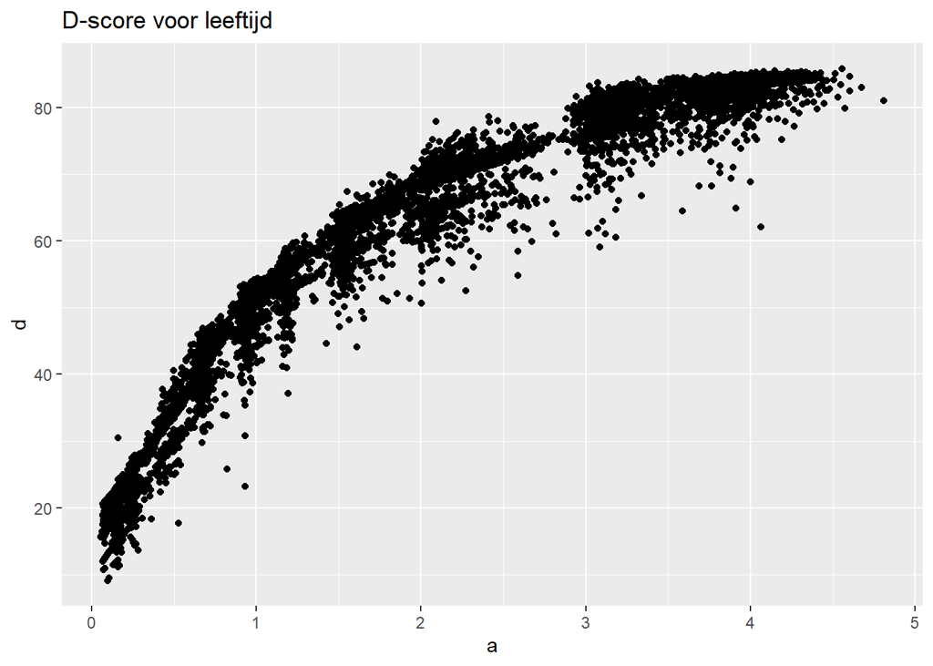

```r
ggplot(dscores, aes(a, d))+
  geom_point() +
  ggtitle("D-score voor leeftijd")
```

- D-score gestandaardizeerd naar leeftijd (daz) voor leeftijd

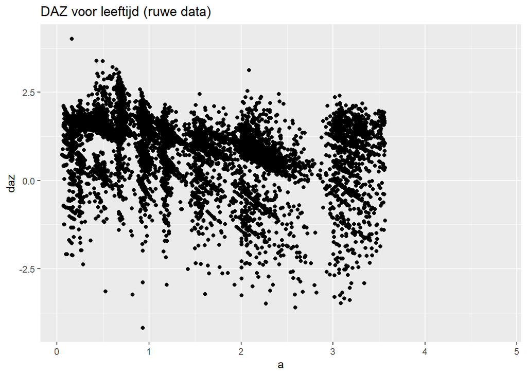

```r
ggplot(dscores, aes(a, daz))+
  geom_point() +
  ggtitle("DAZ voor leeftijd (ruwe data)")
```

- Aantal kenmerken voor leeftijd

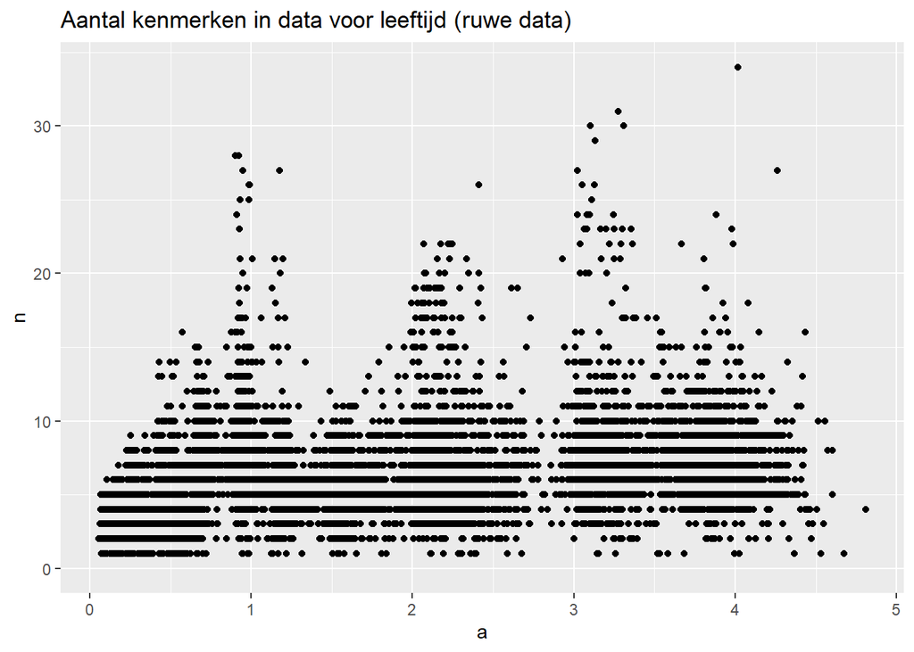

```r
ggplot(dscores, aes(a, n))+
  geom_point() +
  ggtitle("Aantal kenmerken in data voor leeftijd (ruwe data)")
```

- Kans op behalen van afgenomen kenmerken oor leeftijd

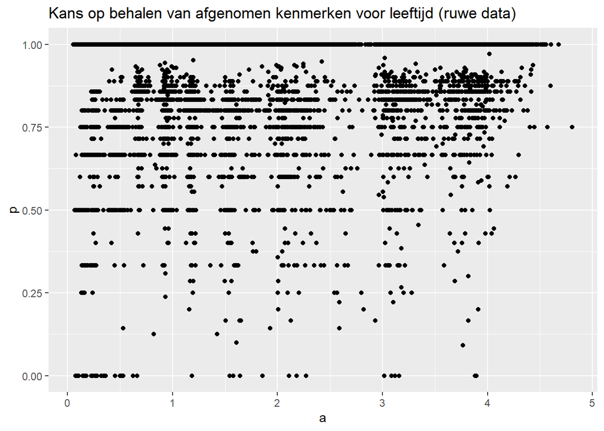

```r
ggplot(dscores, aes(a, p))+
  geom_point() +
  ggtitle("Kans op behalen van afgenomen kenmerken voor leeftijd (ruwe data)")
```

## Verdere selectie van kinderen en datapunten

**Over welke kinderen zeg je iets?**

- woonachtig in periode of woonachtig op peildatum
- voldoende gegevens bekend in groep

**Welke gegevens gebruik je?**

- eerst of laatst bekende in periode?
- meest positieve of meest negatieve in jaar?
- alleen waarnemingen na 6 maanden

## Bepalen van afkappunt voor risicogroep

Op basis van de afwijking van het gemiddelde in de referentie populatie

Keuze van de grens is (nog) arbitrair:

- Onderste 10% is wellicht een groep waar je op kunt interveniëren
- Onder de -2 SD is grens voor indicatie van serieuze problemen in de ontwikkeling
- Of bepalen op basis van populatie sample